# Lab 5

Tyler Smith & Ritika Agrawal

April 8, 2020

# Part 1: Accident Data

### Problem 1.1

```r
#1.1 are there some days of the week where more accidents happen than on others (use variable DAY_WEEK)?

d_count <- count(acc,DAY_WEEK)
d_count
```

```
## # A tibble: 7 x 2
##   DAY_WEEK     n
##      <int> <int>
## 1        1  5360
## 2        2  4374
## 3        3  4347
## 4        4  4314
## 5        5  4621
## 6        6  5358
## 7        7  5873
```

```r
d <- max(d_count)
d
```

```
## [1] 5873
```

Response: Yes. As can be seen from the output, the number of accidents each day varies. The max accidents happen on Day 7 of the week.

### Problem 1.2

```r
#1.2 what time of the day do accidents happen (use variable HOUR)?
h_count <- count(acc,HOUR)
h_count
```

```
## # A tibble: 25 x 2
##     HOUR     n
##    <int> <int>
##  1     0  1321
##  2     1  1177
##  3     2  1241
##  4     3   957
##  5     4   813
##  6     5  1065
##  7     6  1282
##  8     7  1162
##  9     8   945
## 10     9   929
## # ... with 15 more rows
```

```r
h <- max(h_count)
h
```

```
## [1] 2000
```

Response: Accidents happen through the day as can be seen in the output of h_count. The max accidents happen at the 18th hour.

### Problem 1.3

```r
#1.3 what is the number of accidents with at least one drunk driver (use variable DRUNK_DR)?

drunk=subset(acc, acc$DRUNK_DR > 0 )
nrow(drunk)
```

```
## [1] 8769
```

Response: Number of accidents with at least one drunk driver are 8769.

# Part 2: connecting Data

```r
#Filter by Person 1 and join with accident data
part2 <- per %>%
  filter(PER_TYP==1) %>%
  right_join(acc)
```

[output not shown]

```r
#Tally of day_week, hour and sex
day <- part2 %>%
  group_by(DAY_WEEK) %>%
  summarize(count = n())
day$DAY_WEEK <- as.factor(day$DAY_WEEK)
levels(day$DAY_WEEK) <-   c("Su","M","T","W","Th","F","Sa")

hour <- part2 %>%
  group_by(HOUR) %>%
  summarize(hour = n())

part2$SEX <- as.factor(part2$SEX)
levels(part2$SEX) <- c("M","F","U","U")
part2$SEX[is.na(part2$SEX)] <- "U"



sex <- part2 %>%
  group_by(SEX) %>%
  summarize(gender = n())
```

The code above creates the subetted and joined data and then the summarized data frames to eventually tally/visualize the requested results.

### Part 2 Visualizations

```r
day
```

```
## # A tibble: 7 x 2
##   DAY_WEEK count
##   <fct>    <int>
## 1 Su        7773
## 2 M         6837
## 3 T         6755
## 4 W         6791
## 5 Th        7220
## 6 F         8370
## 7 Sa        8618
```

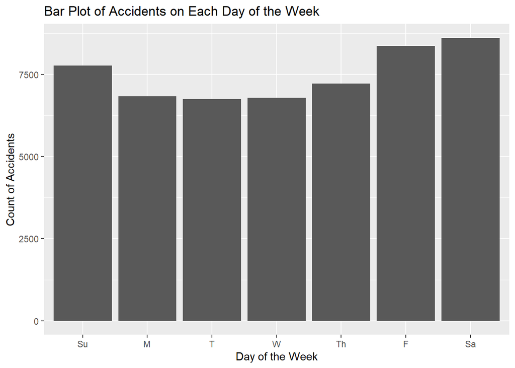

```r
day %>%
  ggplot(aes(x=DAY_WEEK,y=count))+ geom_col() + labs(x="Day of the Week",y="Count of Accidents",title="Bar Plot of Accidents on Each Day of the Week")
```

In the plot above, we see that the weekend dates, Friday and Saturday, both have the most accidents. This is most likely due to most people being off and traveling more on the weekends, plus a likely abundance of drunk driving. There is also a distance third-place with Sunday, also a travel day, but it likely has fewer cases of drunk driving, or perhaps some early in the morning (i.e if someone was up late on Saturday night/Sunday morning).

```r
hour
```

```
## # A tibble: 25 x 2
##     HOUR  hour
##    <int> <int>
##  1     0  1739
##  2     1  1509
##  3     2  1635
##  4     3  1228
##  5     4  1078
##  6     5  1537
##  7     6  1959
##  8     7  1896
##  9     8  1528
## 10     9  1564
## # ... with 15 more rows
```

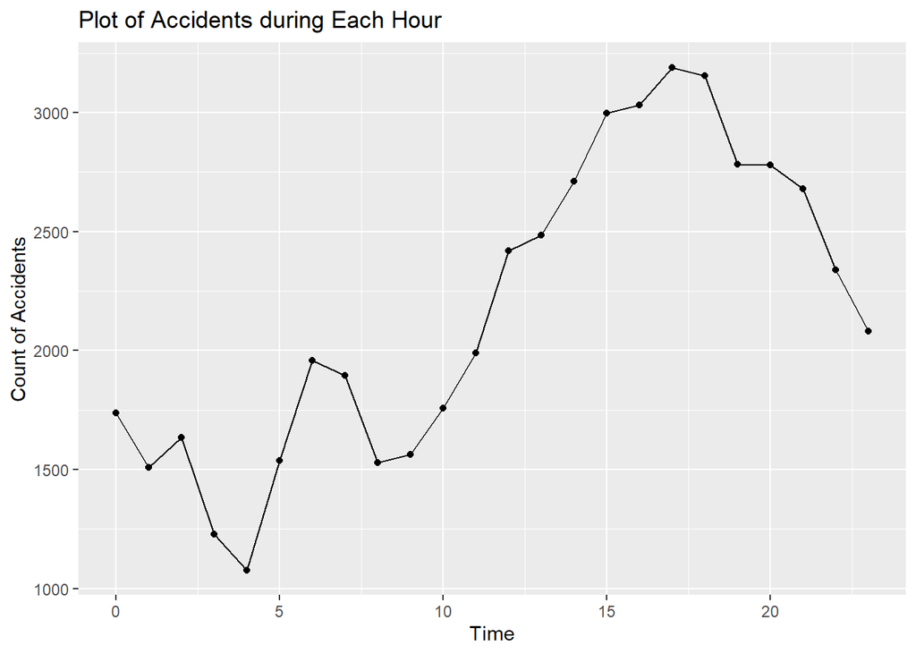

```r
hour %>%
  filter(HOUR<90) %>%
  ggplot(aes(x=HOUR,y=hour))+ geom_line() + geom_point() + labs(x="Time",y="Count of Accidents",title="Plot of Accidents during Each Hour")
```

```r
sex
```

```
## # A tibble: 3 x 2
##   SEX   gender
##   <fct>  <int>
## 1 M      37654
## 2 F      13555
## 3 U       1155
```

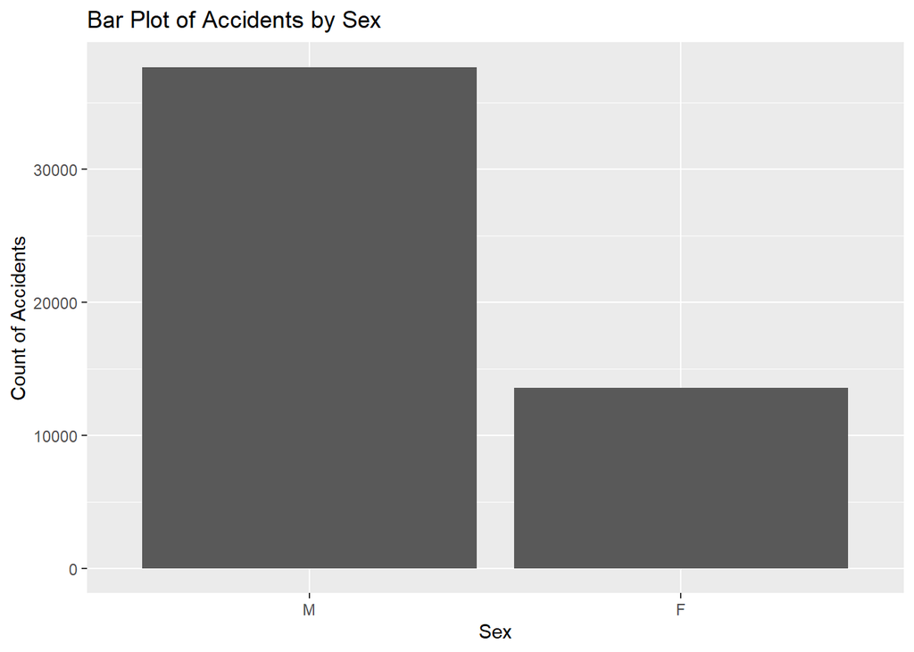

```r
sex %>%
  filter(SEX %in% c("M","F")) %>%
  ggplot(aes(x=SEX,y=gender))+ geom_col() + labs(x="Sex",y="Count of Accidents",title="Bar Plot of Accidents by Sex")
```

The barplot above shows that males appear to have significantly more accidents than females.